# Lab 11: Experimental Design and git

Bios221

2017-07-13

# Goal

In this lab we will see an example of how to use experimental design in a clever way, and how to use packages `pwr` and `RNASeqPower` for power analyses to design your own experiments. Also, we will use git and GitHub as a way to keep track of your code. This will hopefully be useful for you in your future data analysis projects.

# Setup Git and GitHub

1. Sign up for an account: https://github.com/
2. Install GitHub client: https://desktop.github.com/
3. (Optional) Request student discount: https://education.github.com/pack
4. Create new private repository:
   - Go to: https://github.com/YourUserName
   - Select `Repositories` tab
   - Click `New` button
   - Select `Public` (or `Private`) and `Initialize this repository with a README`
   - Edit `README.md`
   - Write and save `README.md`:

   ```
   # Hello World

   This is my first git repository.
   ```

5. Clone your repository
   - Click `Clone or download` green button, then `Open in Desktop`
   - Click `Clone` button to make a local copy of your repository
6. Move today’s `Rmd` file in cloned folder
7. Synchronize your local copy with the one on GitHub
   - Click `1 Uncommitted Change`
   - Write in summary text field:

   ```
   This is my first commit
   ```

   - Click `Commit and Sync master`
8. Continue with the labs, when you are done `Commit and Sync master` to save everything you have done on GitHub

# Packages

Install packages.

```r
pkgs_needed = c("survey","ggplot2","tibble","pwr","RNASeqPower")
letsinstall = setdiff(pkgs_needed, installed.packages())
if (length(letsinstall) > 0) {
  source("http://bioconductor.org/biocLite.R")
  biocLite(letsinstall)
}
```

Load packages.

```r
library("survey")
library("ggplot2")
library("tibble")
library("pwr")
library("RNASeqPower")
```

# Fisher’s Experiment

RA Fisher, one of the fathers of experimental design said: “To consult the statistician after an experiment is finished is often merely to ask him to conduct a post mortem examination. He can perhaps say what the experiment died of.” (Presidential Address to the First Indian Statistical Congress, 1938. Sankhya 4, 14-17).

Experimental design aims to maximize the available resources, capitilizing on cancellations and symmetry are important aspects. Here is a historical illustration of how Hotelling devised an improved weighing scheme.

We are given a set of eight unknown weights $\theta=(\theta_1,\theta_2,\theta_3,\theta_4,\theta_5,\theta_6,\theta_7,\theta_8)$; here we create a true $\theta$ at random.

```r
theta=round((sample(8,8)*2+rnorm(8)),1)
theta
```

```
## [1] 14.1 15.3  5.7 13.7  2.7 10.5  0.6  8.6
```

## Naive method

Suppose we use a chemical scale that weighs each $\theta_i$ individually with errors distributed normally with a sd of 0.1. We compute the vector of errors `errors1` and their variance as follows:

```r
X1to8=theta+rnorm(8,0,0.1)
X1to8
```

```
## [1] 14.178162 15.305463  5.547667 13.614895  2.706799 10.506313  0.496370
## [8]  8.555718
```

```r
errors1=X1to8-theta
errors1
```

```
## [1]  0.078161791  0.005462837 -0.152333087 -0.085104783  0.006798850
## [6]  0.006312737 -0.103630050 -0.044282063
```

```r
var(errors1)
```

```
## [1] 0.00556589
```

## Hotelling’s method

```r
library("survey")
h8 = hadamard(6)
coef8 = 2*h8-1
coef8
```

```
##      [,1] [,2] [,3] [,4] [,5] [,6] [,7] [,8]
## [1,]    1    1    1    1    1    1    1    1
## [2,]    1   -1    1   -1    1   -1    1   -1
## [3,]    1    1   -1   -1    1    1   -1   -1
## [4,]    1   -1   -1    1    1   -1   -1    1
## [5,]    1    1    1    1   -1   -1   -1   -1
## [6,]    1   -1    1   -1   -1    1   -1    1
## [7,]    1    1   -1   -1   -1   -1    1    1
## [8,]    1   -1   -1    1   -1    1    1   -1
```

We use `coef8` as the coefficients in a new weighing scheme:

- The first column puts all the theta on one side of the balance and weighs them
- The second says we place (1,3,5,7) on one side of the balance and (2,4,6,8) on the other and evaluate the difference
- Etc.

So we observe this:

```r
Y = theta  %*% coef8 + rnorm(8,0,0.1)
```

An estimator $\widehat{\theta}$ for $\theta$ is

```r
thetahat = Y %*% t(coef8)/8
```

Here we took advantage of the fact taht `coef8` is a orthogonal matrix, and that the inverse of an orthogonal matrix is its transpose.

Now, because in this case we know the true theta’s we can compute the errors and their variance:

```r
errors2 = as.vector(thetahat - theta)
errors2
```

```
## [1] -3.130829e-03 -1.152634e-02 -1.287128e-02  1.599890e-02 -6.089451e-02
## [6]  4.186942e-05  2.022412e-03  3.804278e-03
```

```r
var(errors2)
```

```
## [1] 0.0005338993
```

We see that this variance is almost an order of magnitude smaller than that of the first procedure. Were we just lucky? To find out, let’s repeat both schemes 10,000 times and look at the sampling distributions of the variances of the errors.

```r
B = 10000
errors1 = matrix(0, nrow = B, ncol = 8)
errors2 = matrix(0, nrow = B, ncol = 8)
tcoef8 = t(coef8)/8
for (i in (1:B)){
  theta = round((1:8)*2 + rnorm(8),1)
  X1to8o = theta+rnorm(8,0,0.1)
  errors1[i,] = X1to8o - theta
  Y = coef8 %*% theta + rnorm(8,0,0.1)
  thetahat = tcoef8 %*% Y
  errors2[i,] = thetahat-theta
}
mean_errors1 = mean(apply(errors1,1,var))
mean_errors1
```

```
## [1] 0.01008565
```

```r
mean_errors2 = mean(apply(errors2,1,var))
mean_errors2
```

```
## [1] 0.001266028
```

```r
mean_errors1/mean_errors2
```

```
## [1] 7.966369
```

**Question**: Can you plot the error ratio distribution? Hint: Take `log10` of the ratios.

Answer:

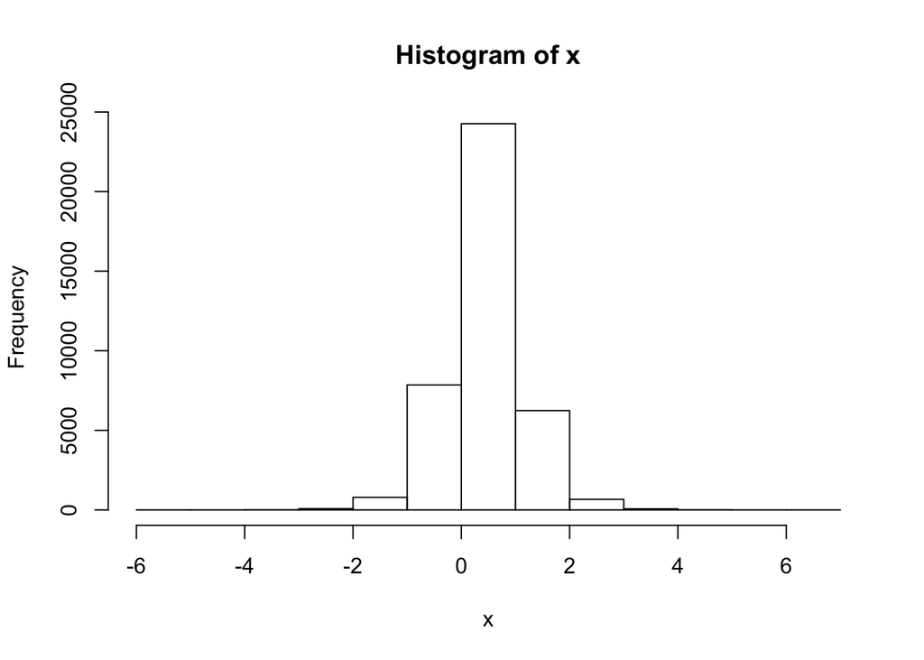

```r
library("ggplot2")
library("tibble")
x=log10(errors1/errors2)
y=log10(apply(errors1,1,var)/apply(errors2,1,var))
hist(x)
```

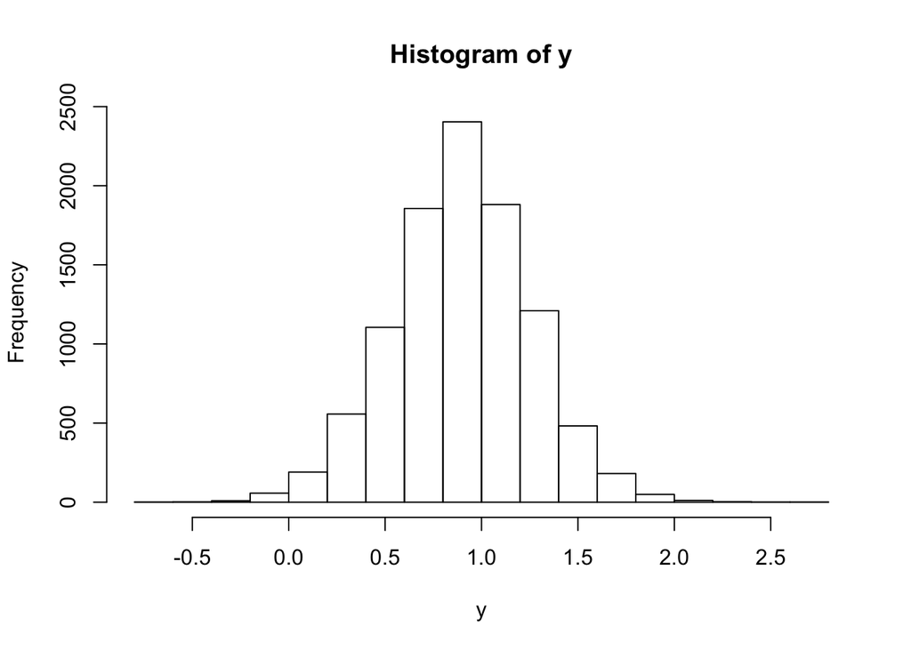

```r
hist(y)
```

```r
#figure<- ggplot(airquality, aes(x = Ozone)) +
        #geom_histogram()
```

The reason we have a smaller variance using the second method is that the objects are weighed several times instead of once. We say that the second scheme is more `efficient` than the first by a factor of 8 because the errors generated by the measurement have a variance which is 8 times lower. This example shows us that when several quantities are to be ascertained there is an opportunity to increase the accuracy and reduce the cost by combining measurements in one experiment and making comparisons between similar groups.

# Power Analysis

## Simple Experiments

The package `pwr` provides functions for doing the standard power calculations. There are always four quantities involved in these computations: sample size, effect size, significance level (false positive rate) and the power itself which is the probability of rejecting a hypothesis when you should (true positive rate). The functions `pwr.2p.test`, `pwr.chisq.test`, and `pwr.f2.test` provide the calculations for tests of two proportions, the chisquared test and general linear tests respectively.

Here is an example of the power calculcation for a two sample t-test with $n=15$. The functions requires several arguments:

```
pwr.t.test(n = NULL, d = NULL, sig.level = 0.05, power = NULL,
    type = c("two.sample", "one.sample", "paired"),
    alternative = c("two.sided", "less", "greater"))
```

If you enter a value for the power and the effect size, it will return the sample size needed, or if you enter the sample size and effect size it returns the power:

```r
library("pwr")
pwr.t.test(n=15,d=0.4,sig.level=0.05,type="two.sample")
```

```
##
##      Two-sample t test power calculation
##
##               n = 15
##               d = 0.4
##       sig.level = 0.05
##           power = 0.1848496
##     alternative = two.sided
##
## NOTE: n is number in *each* group
```

```r
pwr.t.test(n=15,d=0.4,sig.level=0.05,type="paired")
```

```
##
##      Paired t test power calculation
##
##               n = 15
##               d = 0.4
##       sig.level = 0.05
##           power = 0.3031649
##     alternative = two.sided
##
## NOTE: n is number of *pairs*
```

If we want to know what sample size would be required to detect a given effect size:

```r
library("pwr")
pwr.t.test(d=0.4,sig.level=0.05,type="two.sample",power=0.8)
```

```
##
##      Two-sample t test power calculation
##
##               n = 99.08032
##               d = 0.4
##       sig.level = 0.05
##           power = 0.8
##     alternative = two.sided
##
## NOTE: n is number in *each* group
```

```r
pwr.t.test(d=0.4,sig.level=0.05,type="paired",power=0.8)
```

```
##
##      Paired t test power calculation
##
##               n = 51.00945
##               d = 0.4
##       sig.level = 0.05
##           power = 0.8
##     alternative = two.sided
##
## NOTE: n is number of *pairs*
```

We see that we would need twice as many observations for the same power when not pairing the experiment.

Some power calculations need more than the sample and effect size, they alse need the relative size of the standard deviation to the mean, called the coefficient of variation $cv=\sigma/\mu$.

## RNASeq Experiments

For highthroughput studies such RNA-seq the package `RNASeqPower` has the same type of input. However, there are more important quantities to take into account:

- The depth of sequencing and consequent expected count for a given transcript, argument depth
- The coefficient of variation of counts within each of the two groups, argument cv
- The relative expression that we wish to detect $\Delta$, argument effect
- The target false positive rate $\alpha$ and false negative rate $\beta$ or power $= 1-\beta$, arguments alpha and power
- The number of samples n in each group, argument n

We often do not know some of the true values for our input so we do our calculations at many tentative values, creating an abaque or grid of possible values within the limits that we think will cover our experiment:

```r
library("RNASeqPower")
rnapower(depth=20, cv=.4, effect=c(1.25, 1.5, 1.75, 2),
             alpha= .05, power=c(.7,.8, .9))
```

```
##            0.7       0.8       0.9
## 1.25 52.060848 66.204618 88.629200
## 1.5  15.767867 20.051644 26.843463
## 1.75  8.277515 10.526332 14.091771
## 2     5.395466  6.861294  9.185326
```

```r
rnapower(depth=200, cv=.4, effect=c(1.25, 1.5, 1.75, 2),
             alpha= .05, power=c(.7,.8, .9))
```

```
##            0.7       0.8       0.9
## 1.25 40.904952 52.017914 69.637228
## 1.5  12.389038 15.754863 21.091292
## 1.75  6.503762  8.270689 11.072106
## 2     4.239295  5.391017  7.217042
```

We see a table of values.